# R Notebook

```r
include <- function(library_name){
  if ( !(library_name %in% installed.packages()))
    install.packages((library_name))
  library(library_name, character.only = TRUE)
}
include("rvest")
```

```r
include("tidyr")
include("ggplot2")
```

pulling in air quality data

```r
data("airquality")
air <- as_tibble(airquality)
cor.test(air$Ozone,air$Temp)
```

```
##
##  Pearson's product-moment correlation
##
## data:  air$Ozone and air$Temp
## t = 10.418, df = 114, p-value < 2.2e-16
## alternative hypothesis: true correlation is not equal to 0
## 95 percent confidence interval:
##  0.5913340 0.7812111
## sample estimates:
##       cor
## 0.6983603
```

now that we have a correlation test, lets visual some of this data with `ggplot`

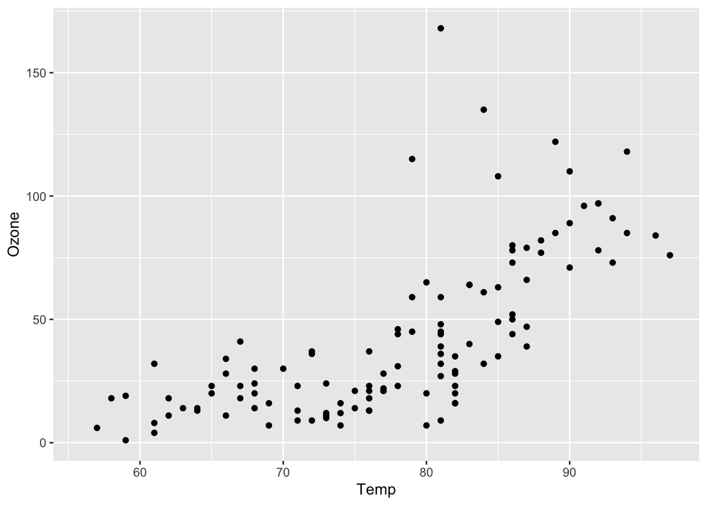

```r
graph <- ggplot(air, aes(x = Temp, y = Ozone)) + geom_point()
print(graph)
```

we want to get a statistical analysis for our variables

```r
simple_model <- lm(air, formula=Ozone~Temp)
summary(simple_model)
```

```
##
## Call:
## lm(formula = Ozone ~ Temp, data = air)
##
## Residuals:
##     Min      1Q  Median      3Q     Max
## -40.729 -17.409  -0.587  11.306 118.271
##
## Coefficients:
##              Estimate Std. Error t value Pr(>|t|)
## (Intercept) -146.9955    18.2872  -8.038 9.37e-13 ***
## Temp           2.4287     0.2331  10.418  < 2e-16 ***
## ---
## Signif. codes:  0 '***' 0.001 '**' 0.01 '*' 0.05 '.' 0.1 ' ' 1
##
## Residual standard error: 23.71 on 114 degrees of freedom
##   (37 observations deleted due to missingness)
## Multiple R-squared:  0.4877, Adjusted R-squared:  0.4832
## F-statistic: 108.5 on 1 and 114 DF,  p-value: < 2.2e-16
```

now we’re going to step up our game and build a more sophisticated model

we’re going to need a couple vocabulary terms: multivariate models - trying to predict more than just one variable, this model measures multiple variables at one time.

multiple linear regression - instead of using one factor to help us in our prediction, we;re going to use mulitple variables

we’re going to create a new model

```r
quality_model <- lm(air, formula=Ozone ~ Solar.R + Wind + Temp + Month + Day)
summary(quality_model)
```

```
##
## Call:
## lm(formula = Ozone ~ Solar.R + Wind + Temp + Month + Day, data = air)
##
## Residuals:
##     Min      1Q  Median      3Q     Max
## -37.014 -12.284  -3.302   8.454  95.348
##
## Coefficients:
##              Estimate Std. Error t value Pr(>|t|)
## (Intercept) -64.11632   23.48249  -2.730  0.00742 **
## Solar.R       0.05027    0.02342   2.147  0.03411 *
## Wind         -3.31844    0.64451  -5.149 1.23e-06 ***
## Temp          1.89579    0.27389   6.922 3.66e-10 ***
## Month        -3.03996    1.51346  -2.009  0.04714 *
## Day           0.27388    0.22967   1.192  0.23576
## ---
## Signif. codes:  0 '***' 0.001 '**' 0.01 '*' 0.05 '.' 0.1 ' ' 1
##
## Residual standard error: 20.86 on 105 degrees of freedom
##   (42 observations deleted due to missingness)
## Multiple R-squared:  0.6249, Adjusted R-squared:  0.6071
## F-statistic: 34.99 on 5 and 105 DF,  p-value: < 2.2e-16
```

since we have multiple variables now, we’re not just talking about that one variable in isolation, we’re considering if that variable would even matter if it were in the model anyway. for example, the variable `Day` has no need to be in the data at all. in fact, the model might be better if we didn’t have `Day` in there at all